# Assignment 3

# PART B

Problem 4

Write a function that performs cross-validation for a linear model (fit using lm) and returns the average root-mean-square-error across all folds. The function should take as arguments (1) a formula used to fit the model, (2) a dataset, and (3) the number of folds to use for cross-validation. The function should partition the dataset, fit a model on each training partition, make predictions on each test partition, and return the average root-mean-square-error.

```r
cross_validation <- function(fitted, datasetq4, k){
  Housing_cv <- crossv_kfold(datasetq4, k)
  Housing_cv = Housing_cv %>% mutate(fit = purrr::map(train, ~lm(fitted, data = .))) %>%
    mutate(rmse_val = map2_dbl(fit, test, rmse))
    mean_rmse <- mean(Housing_cv$rmse_val)
    return(mean_rmse)
}

fitted <- log2(crim) ~ log2(dis)+log2(rad)

cross_validation(fitted, BostonHousing, 10)
```

```
## [1] 1.312546
```

Problem 5

Use your function from Problem 4 to compare the models you used from Part A with 5-fold cross-validation. Report the cross-validated root-mean-square-error for the models from Problems 1 and 3. Which model was more predictive?

```r
#fit is the model being used in Problem 1.

#fit <- lm(log2(crim) ~ log2(dis), data=BostonHousing)
#fit

cross_validation(fit, BostonHousing, 5)
```

```
## [1] 2.085896
```

```r
#fit3 is the model being used in Problem 3.

#fit3 <- lm(log2(crim) ~ log2(dis)+log2(rad), data=BostonHousing)
#fit3

cross_validation(fit3, BostonHousing, 5)
```

```
## [1] 1.326191
```

```r
# The model derived in problem 3 is predictable and it's evident from the cross-validated root-mean-square-error value. The previous model's cv-rmse of model dervied from problem 1 is bit high comparitively.
```

# Part C

Problem 6

```r
# rm("fit1", "fit2", "fit3")

C_Data <- readLines("C:/Users/mouni/Downloads/Sem 1/R Lang/Datasets/full_speech.txt")

Trump <- tibble(line=1:length(C_Data), text=C_Data)

Trump_words <- unnest_tokens(Trump, word, text)
print(Trump_words, n=10)
```

```
## # A tibble: 236,368 x 2
##     line word
##    <int> <chr>
##  1     1 trump
##  2     1 wow
##  3     1 whoa
##  4     1 that
##  5     1 is
##  6     1 some
##  7     1 group
##  8     1 of
##  9     1 people
## 10     1 thousands
## # ... with 2.364e+05 more rows
```

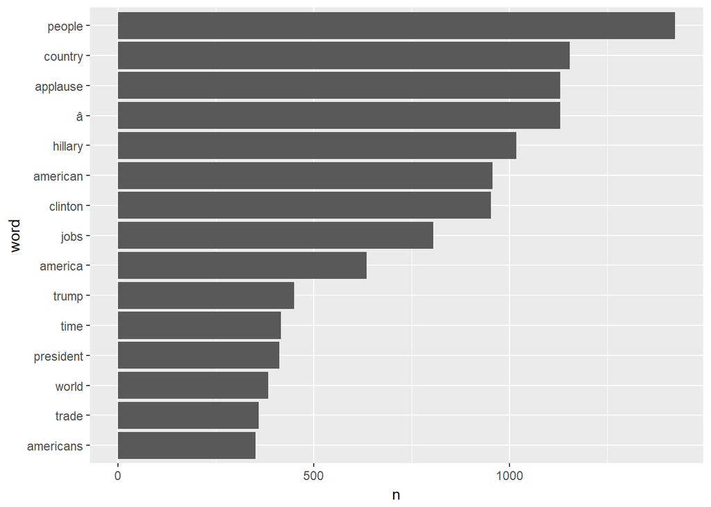

```r
Trump_words %>%
  anti_join(stop_words, by="word") %>%
  count(word, sort=TRUE) %>%
  top_n(15) %>%
  mutate(word = reorder(word, n)) %>%
  ggplot(aes(x=word, y=n)) +
  geom_col() +
  coord_flip()
```

Problem 7

Re-tokenize the text of all 56 Donald Trump Speeches into a new tidy text data frame, using bigrams as tokens. Remove each bigram where either word is a stop word or the word “applause”. Then plot the top 15 most common bigrams in Trump’s speeches.

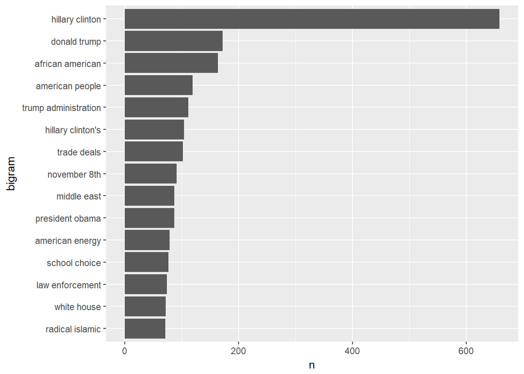

```r
Trump_bigrams <- Trump %>%
  unnest_tokens(bigram, text, token = "ngrams", n = 2)

Trump_bigrams <- Trump_bigrams %>%
  separate(bigram, c("word1", "word2"), sep = " ") %>%
  filter(!word1 %in% stop_words$word) %>%
  filter(!word2 %in% stop_words$word) %>%
  filter(!word1 == "applause") %>%
  filter(!word2 == "applause")

Trump_bigrams %>%
  unite(bigram, word1, word2, sep = " ") %>%
  count(bigram, sort=TRUE) %>%
  top_n(15) %>%
  mutate(bigram = factor(bigram, levels = rev(unique(bigram))))  %>%
  ggplot(aes(x=bigram, y=n)) +
  geom_col() +
  coord_flip()
```

Problem 8

We would like to do a sentiment analysis of Donald Trump’s speeches. In order to make sure sentiments are assigned to appropriate contexts, first tokenize the speeches into bigrams, and then filter out all bigrams where the first word is any of “not”, “no”, or “never”.

Now consider only the second word of each bigram. After filtering out the words “applause” and “trump”, create a plot of the 10 most common words in Trump’s speeches that are associated with each of the 10 sentiments in the “nrc” lexicon.

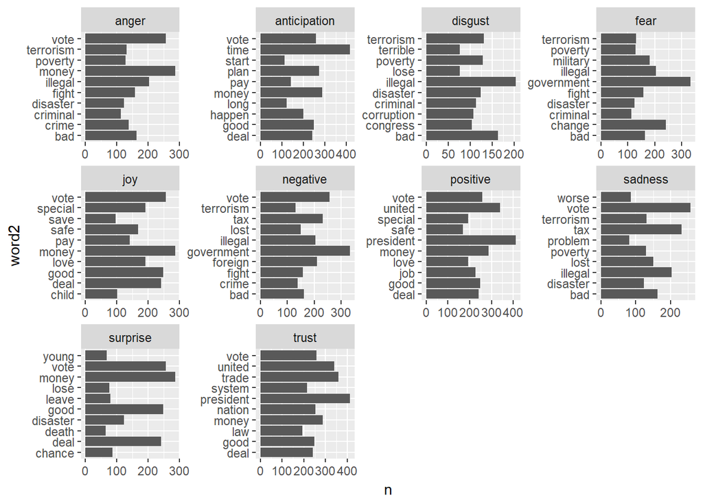

```r
Trump_sentiment <- Trump %>%
  unnest_tokens(bigram, text, token = "ngrams", n = 2)

Trump_sentiment <- Trump_sentiment %>%
  separate(bigram, c("word1", "word2"), sep = " ") %>%
  filter(!word1 == "not" | !word1 == "no" | !word1 == "never") %>%
  filter(!word2 == "applause" & !word2 == "trump")

nrcjoy <- get_sentiments("nrc")

Trump_sentiment %>%
  inner_join(nrcjoy, by = c("word2" = "word")) %>%
  group_by(sentiment) %>%
  count(word2, sort = TRUE) %>%
  mutate(word2 = reorder(word2, n)) %>%
  top_n(10) %>%
  ggplot(aes(word2, n)) +
  geom_col(show.legend = FALSE) +
  facet_wrap(~sentiment, scales="free") +
  coord_flip()
```

Problem 9

Create an S3 class called tidy_corpus which inherits from a tibble (tbl_df). A tidy_corpus is a tidy text data frame that always has at least one column called token, which gives the tokens, and an attribute called token_type which gives the type of token. A tidy_corpus object may also have an additional attribute called n when token_type is “ngrams”.

Create a constructor function that creates tidy_corpus objects called tidy_corpus(src, token, …) which takes three parameters: . src is either a character vector or a directory of text files . token gives the kind of tokenization to be performed . … are additional arguments passed to unnest_tokens()

Write a plot() method for the tidy_corpus class that plots the top n most common tokens in the corpus where n is a user parameter defaulting to 10. Include an optional parameter for removing stop words. The removal of stop words should support at least words and bigrams.

Test your class and methods on the data in Part C.

```r
# Creating an S3 class

C_Text <- read_lines("C:/Users/mouni/Downloads/Sem 1/R Lang/Datasets/full_speech.txt")

tidy_corpus <- function(src, token, ...) {
if (any(grepl(".*.txt", src))) {
src <- read_lines(src)
}
corpus_tbl <- tibble(line=1:length(src), words = src)
corpus <- unnest_tokens(corpus_tbl, token = token, output = token, input = words, ...)
corpus <- structure(corpus, class = c("tbl_df", "tbl", "data.frame"))
element <- structure(list(corpus = corpus, token_type = token, ...), class = c("tidy_corpus"))
return(element)
}

# determine object type (whether "S3") with otype using speech file and words as arguments to tidy_corpus function created.

otype(tidy_corpus("C:/Users/mouni/Downloads/Sem 1/R Lang/Datasets/full_speech.txt", token = "words"))
```

```
## [1] "S3"
```

```r
# creating a function/method called plot

plot <- function(x) UseMethod("plot")

plot.tidy_corpus <- function(rand, n=10, rm_stop_words=FALSE) {
  if (length(rand)==2) {
    corpus <- rand$corpus
    token_type <- rand$token_type
    } else if (length(rand)==3) {
      corpus <- rand$corpus
      token_type <- rand$token_type
      n_grams <- rand$n
    }
  if (token_type=="words") {
    if (rm_stop_words==TRUE) {
      corpus %>%
        anti_join(stop_words, by=c("token"="word")) %>%
        count(token, sort=TRUE) %>%
        top_n(n) %>%
        mutate(token = reorder(token, n)) %>%
        ggplot(aes(x=token, y=n)) + geom_col() +
        coord_flip()
      } else {
        corpus %>%
          count(token, sort=TRUE) %>%
          top_n(n) %>%
          mutate(token = reorder(token, n)) %>%
          ggplot(aes(x=token, y=n)) + geom_col() +
          coord_flip()
      }
    } else if (token_type=="ngrams" && n_grams==2) {
      if (rm_stop_words==TRUE) {
        corpus <- corpus %>%
          separate(token, c("word1", "word2"), sep = " ")

        corpus <- corpus %>%
          filter((!word1 %in% stop_words$word)) %>%
          filter((!word2 %in% stop_words$word))

        corpus %>%
          unite(col = token, c("word1","word2"), sep=" ") %>%
          count(token, sort=TRUE) %>%
          top_n(n) %>%
          mutate(token = reorder(token, n)) %>%
          ggplot(aes(x=token, y=n)) + geom_col() +
          coord_flip()
        } else {
          corpus %>%
            count(token, sort=TRUE) %>%
            top_n(n) %>%
            mutate(bigrams = reorder(token, n)) %>%
            ggplot(aes(x=token, y=n)) + geom_col() +
            coord_flip()
        }
      } else {
        corpus %>%
          count(token, sort=TRUE) %>%
          top_n(n) %>%
          mutate(token = reorder(token, n)) %>%
          ggplot(aes(x=token, y=n)) + geom_col() +
          coord_flip()
      }
}
```

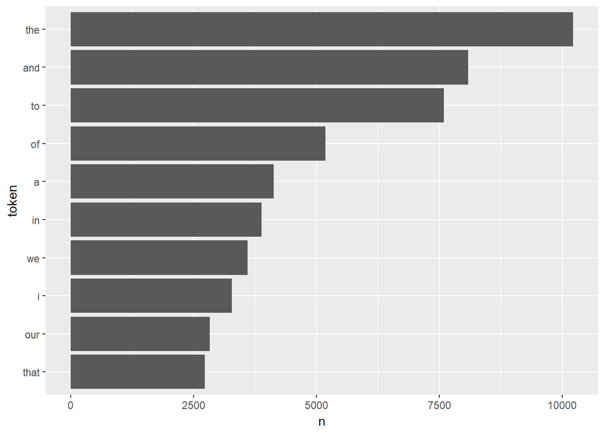

```r
# check the tidy_corpus class with different arguments.

# (1) src as "c_Text" and tokens as "unigrams/words"
check_tidy_corpus <- tidy_corpus(src= C_Text, token= "words")
#check_tidy_corpus

# Non-removal of stop words
plot.tidy_corpus(check_tidy_corpus, n=10, rm_stop_words=FALSE)
```

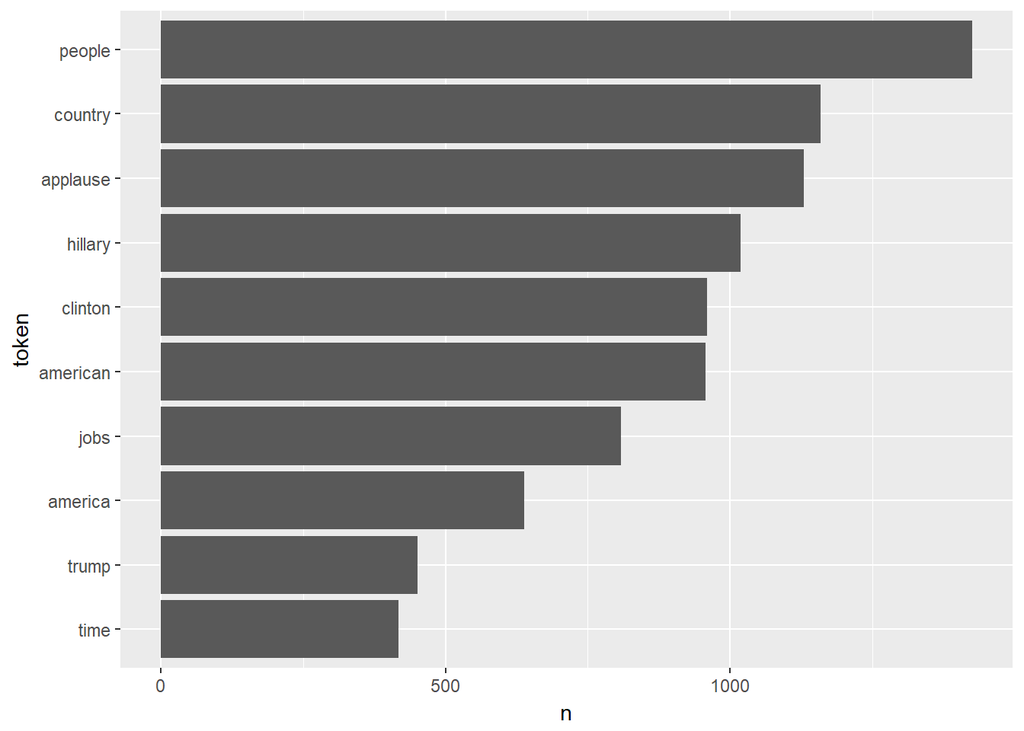

```r
# Removal of stop words
plot.tidy_corpus(check_tidy_corpus, n=10, rm_stop_words=TRUE)
```

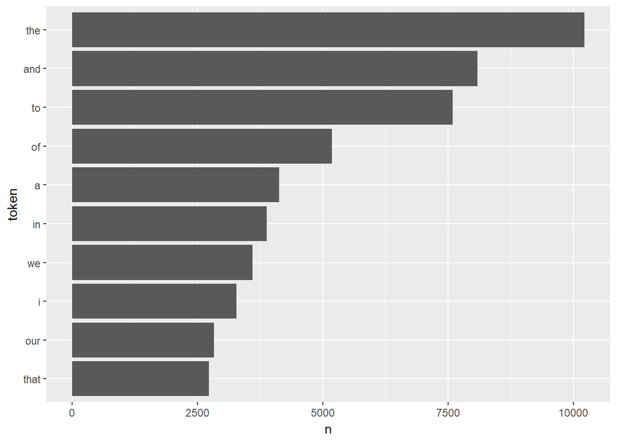

```r
# (2) src as a "directory" and tokens as "unigrams/words"
check_tidy_corpus <- tidy_corpus("C:/Users/mouni/Downloads/Sem 1/R Lang/Datasets/full_speech.txt", token = "words")
#check_tidy_corpus

# Non-removal of stop words
plot.tidy_corpus(check_tidy_corpus, n=10, rm_stop_words=FALSE)
```

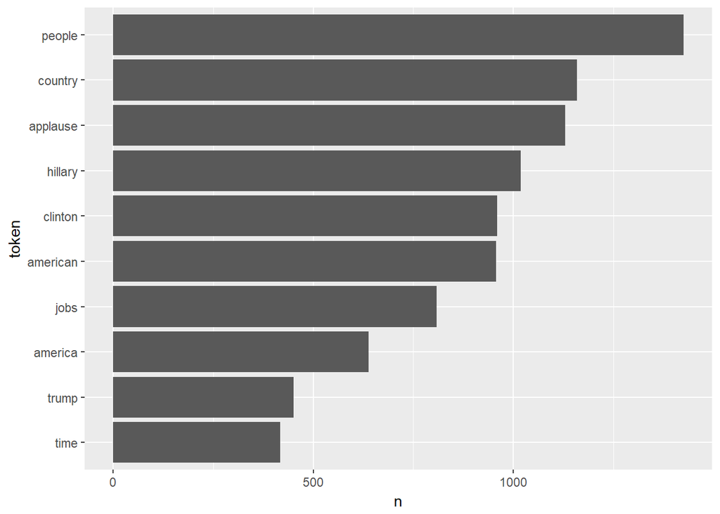

```r
# Removal of stop words
plot.tidy_corpus(check_tidy_corpus, n=10, rm_stop_words=TRUE)
```

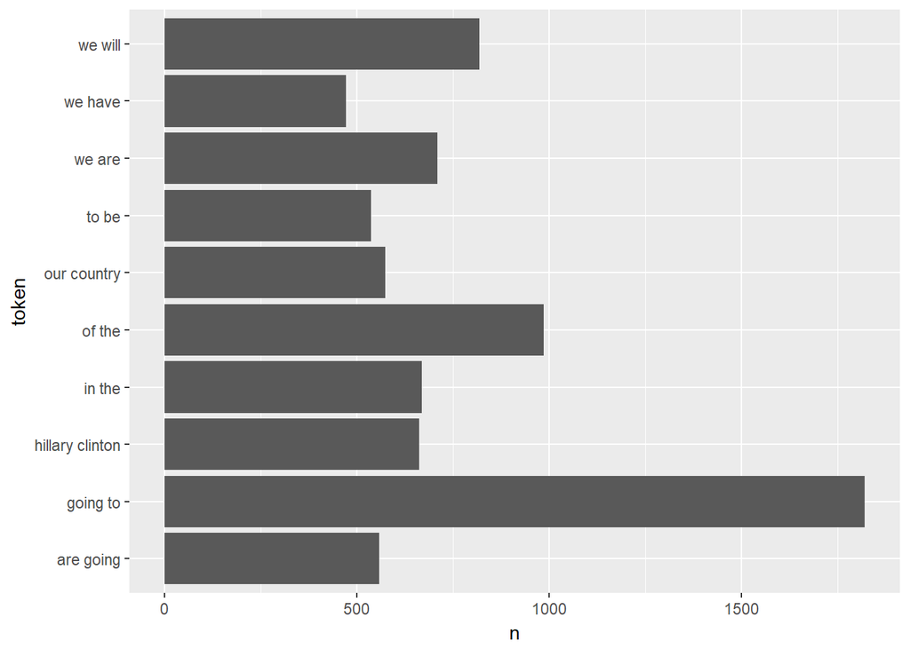

```r
# (3) src as a "directory" and tokens as "bigrams"
check_tidy_corpus_bi <- tidy_corpus("C:/Users/mouni/Downloads/Sem 1/R Lang/Datasets/full_speech.txt", token = "ngrams", n = 2)
#check_tidy_corpus_bi
# Non-removal of stop words
plot.tidy_corpus(check_tidy_corpus_bi, n=10, rm_stop_words=FALSE)
```

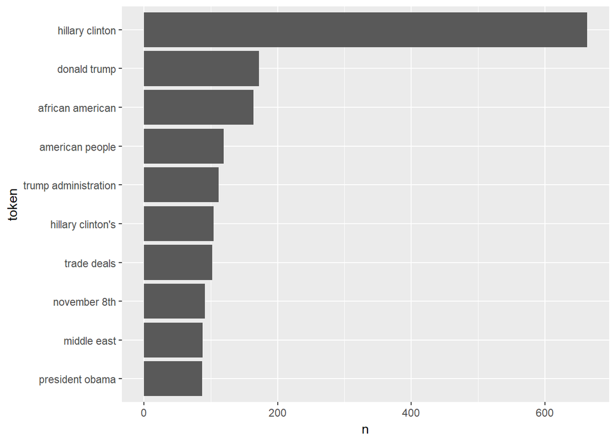

```r
# Removal of stop words
plot.tidy_corpus(check_tidy_corpus_bi, n = 10, rm_stop_words = TRUE)
```

```r
# (4) src as a "directory" and tokens as "trigrams"
check_tidy_corpus <- tidy_corpus("C:/Users/mouni/Downloads/Sem 1/R Lang/Datasets/full_speech.txt", token = "ngrams", n = 3)
check_tidy_corpus
```

```
## $corpus
## # A tibble: 235,089 x 2
##     line token
##  * <int> <chr>
##  1     1 trump wow whoa
##  2     1 wow whoa that
##  3     1 whoa that is
##  4     1 that is some
##  5     1 is some group
##  6     1 some group of
##  7     1 group of people
##  8     1 of people thousands
##  9     1 people thousands so
## 10     1 thousands so nice
## # ... with 235,079 more rows
##
## $token_type
## [1] "ngrams"
##
## $n
## [1] 3
##
## attr(,"class")
## [1] "tidy_corpus"
```

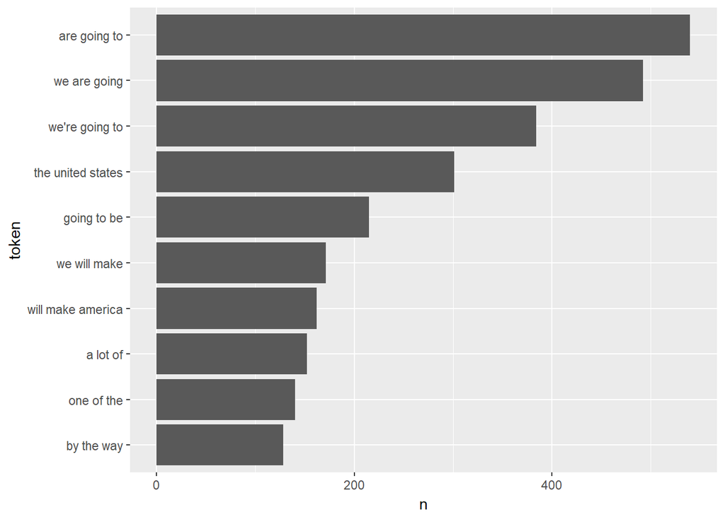

```r
# Non-removal of stop words
plot.tidy_corpus(check_tidy_corpus, n=10, rm_stop_words=FALSE)
```

Problem 10

Create an R package for the class and methods you created in Problem 9. For full credit, it should pass R CMD check without errors. (Warnings are okay. You do not need to include documentation.) Build the package and include the .tar.gz compressed file in your homework directory.

```r
# Creating an R package for the class and methods created in Problem 9

#package.skeleton(name = "tidycorpus", list=c("tidy_corpus", "plot", "plot.tidy_corpus"))

# commenting out the package creation code as the package has already been created and it might throw an error.

# install the created package
install("tidycorpus")
```

```
## Installing tidycorpus
```

```
## "C:/PROGRA~1/R/R-34~1.3/bin/x64/R" --no-site-file --no-environ --no-save --no-restore  \
##   --quiet CMD INSTALL "C:/Users/mouni/OneDrive/Documents/tidycorpus"  \
##   --library="C:/Users/mouni/OneDrive/Documents/R/win-library/3.4" --install-tests
```

```r
# load the package
library("tidycorpus")
# R Check
check("tidycorpus")
```

```
## Updating tidycorpus documentation
```

```
## Loading tidycorpus
```

```
## First time using roxygen2. Upgrading automatically...
```

```
## Setting env vars ------------------------------------------------------------------------
```

```
## CFLAGS  : -Wall -pedantic
## CXXFLAGS: -Wall -pedantic
```

```
## Building tidycorpus ---------------------------------------------------------------------
```

```
## "C:/PROGRA~1/R/R-34~1.3/bin/x64/R" --no-site-file --no-environ --no-save --no-restore  \
##   --quiet CMD build "C:\Users\mouni\OneDrive\Documents\tidycorpus" --no-resave-data  \
##   --no-manual
```

```
## Setting env vars ------------------------------------------------------------------------
```

```
## _R_CHECK_CRAN_INCOMING_ : FALSE
## _R_CHECK_FORCE_SUGGESTS_: FALSE
```

```
## Checking tidycorpus ---------------------------------------------------------------------
```

```
## "C:/PROGRA~1/R/R-34~1.3/bin/x64/R" --no-site-file --no-environ --no-save --no-restore  \
##   --quiet CMD check  \
##   "C:\Users\mouni\AppData\Local\Temp\Rtmpq69Yrm/tidycorpus_1.0.tar.gz" --as-cran  \
##   --timings --no-manual
```

```
## R CMD check results
```

```
## 0 errors | 2 warnings | 2 notes
```

[output not shown]

```r
# compressing the file
library(utils)
tar("tidycorpus.tar.gz", "C:/Users/mouni/OneDrive/Documents/tidycorpus", compression = "gzip", tar = "tar")
```